# A Session to understand Pandas and Seaborn

Saptarishi, Anton

2023-04-21

# Briefing

The goal of this session was to understand a python codechunk and recreate it (if possible, better) with minor modifications.

# The Problem: Code Chunk

```python
import pandas as pd
import seaborn as sns
import matplotlib.pyplot as plt
import numpy as np

sns.set_theme(style="darkgrid",palette="pastel")
df = pd.DataFrame(columns=["RGCs","SC", "LGN", "V1"])
df.loc[0, "RGCs"] = [4.3*10**5, 8.3*10**5,9.3*10**4]
df.loc[0, "SC"] = [6.2*10**5,5.8*10**5,7.6*10**5,5.5*10**5]
df.loc[0, "LGN"] = [1.4*10**5,3.1*10**5,2.5*10**5]
df.loc[0, "V1"] = [1.2*10**6,1.1*10**5,1.8*10**6,5.1*10**6,2.7*10**6,9.3*10**5,2.6*10**6]

plt.figure()

RGCs_mean = np.mean(df["RGCs"][0])
SC_mean = np.mean(df["SC"][0])
LGN_mean = np.mean(df["LGN"][0])
V1_mean = np.mean(df["V1"][0])
RGCs_std = np.std(df["RGCs"][0])
SC_std = np.std(df["SC"][0])
LGN_std = np.std(df["LGN"][0])
V1_std = np.std(df["V1"][0])

plt.bar([0,1,2,3],[RGCs_mean, SC_mean,LGN_mean,V1_mean], width=0.5)
```

```
## <BarContainer object of 4 artists>
```

```python
plt.errorbar([0,1,2,3], [RGCs_mean, SC_mean,LGN_mean,V1_mean], yerr=[RGCs_std, SC_std,LGN_std,V1_std], fmt='none', ecolor='black', capsize=3)
```

```
## <ErrorbarContainer object of 3 artists>
```

```python
plt.scatter([0]*len(df["RGCs"][0]), df["RGCs"][0],color="purple",marker="x")
plt.scatter([1]*len(df["SC"][0]), df["SC"][0], color="blue",marker="x")
plt.scatter([2]*len(df["LGN"][0]), df["LGN"][0], color="red",marker="x")
plt.scatter([3]*len(df["V1"][0]), df["V1"][0], color="green",marker="x")

plt.xticks([0, 1,2,3], ["RGCs", "SC","LGN","V1"])
```

```
## ([<matplotlib.axis.XTick object at 0x7fcb46090340>, <matplotlib.axis.XTick object at 0x7fcb46090310>, <matplotlib.axis.XTick object at 0x7fcb4605b2b0>, <matplotlib.axis.XTick object at 0x7fcb45d5edd0>], [Text(0, 0, 'RGCs'), Text(1, 0, 'SC'), Text(2, 0, 'LGN'), Text(3, 0, 'V1')])
```

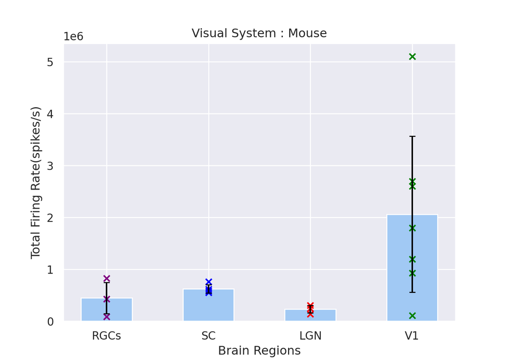

```python
plt.xlabel('Brain Regions')
plt.ylabel('Total Firing Rate(spikes/s)')
plt.title("Visual System : Mouse")

plt.show()
```

# Our Solution

## Note

The problem with the previous dataframe was that the rows for a column were clubbed together in a single cell of the dataframe, which made it very difficult to access the values.

Due to the nature of the data, we considered to construct the dataframe in long format. This was just done to get started, we will try to improve on a more “real” way of gathering or writing the preprocessed data.

### Creating the dataframe df2

First we noted down all the Cell Types and Characters/markers we wanted them to be represented with

```python
Types = np.array(["RGC","SC", "LGN","VI"])
Character = np.array(["X","O"])
```

Next, we put this data into a data frame (df2)

```python
df2 = pd.DataFrame({
    'Type':np.repeat(Types,[3,4,5,7]),
    'Values':np.array([1,4,77,7,21,14,15,3,24,55,67,14,8,9,5,2,11,14,11])

})
```

Then, since the assignment of markers was very random, we couldn’t find an easier way to add it to column of the df2. We thus wrote it down ‘by-hand’ in a new column of the ‘df2’.

```python
df2["Character"] = np.array(["X","X","O",
                                       "X","X","X","O",
                                       "X","X","X","X","O",
                                       "X","X","O","O","O","O","O"])
```

Now, looking at the first 5 values of the dataframe - df2 (Just to ensure its alright)

```python
df2.head()
```

```
##   Type  Values Character
## 0  RGC       1         X
## 1  RGC       4         X
## 2  RGC      77         O
## 3   SC       7         X
## 4   SC      21         X
```

### Finding the mean using groupby() method of pandas dataframe

```python
df2['Values_New'] = pd.to_numeric(df2['Values'])
```

Then, we grouped the dataframe values using Type and CHaracter to then find mean of Values_New

```python
df2['Mean'] = df2.groupby(['Type', 'Character'])['Values_New'].transform('mean')
```

Similarly we found the standard deviation - std

```python
df2['Std'] = df2.groupby(['Type','Character'])['Values_New'].transform('std').fillna(0)
```

Checking the modified df2 with added columns of mean and sd

```python
df2.head()
```

```
##   Type  Values Character  Values_New  Mean      Std
## 0  RGC       1         X           1   2.5  2.12132
## 1  RGC       4         X           4   2.5  2.12132
## 2  RGC      77         O          77  77.0  0.00000
## 3   SC       7         X           7  14.0  7.00000
## 4   SC      21         X          21  14.0  7.00000
```

### Plotting

Final Plot just using seaborn library

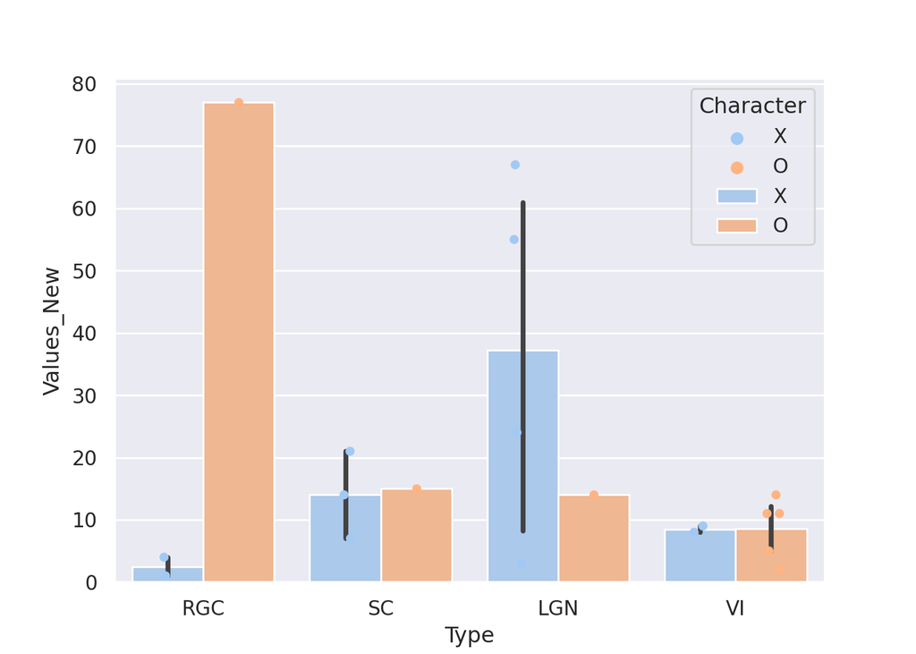

```python
plt.clf()
sns.barplot(data = df2, x ="Type", hue= "Character", y ="Values_New")
sns.stripplot(data = df2, x ="Type", hue= "Character", y ="Values_New", dodge = True)

plt.show()
```